# Assignment 2

```r
library(tidyverse)
```

## 1.

```r
MyData1 <- read.csv(file="feellucky.csv", header=TRUE, sep=",")
MyData1
```

| luck |
| --- |
| 1 |
| 10 |
| 1 |
| 10 |
| 1 |
| 1 |
| 10 |
| 5 |
| 1 |
| 1 |

[output cut: 50 more lines]

The data looks correct even though there is only one column in the data file.

```r
t.test(MyData1$luck, conf.level = 0.99)
```

```
    One Sample t-test

data:  MyData1$luck
t = 12.116, df = 59, p-value < 2.2e-16
alternative hypothesis: true mean is not equal to 0
99 percent confidence interval:
 4.603861 7.196139
sample estimates:
mean of x
      5.9
```

Here we can see the mean of `luck` from the 99% CI is 5.9.

```r
t.test(MyData1$luck, mu = 5.5, alternative="greater")
```

```
    One Sample t-test

data:  MyData1$luck
t = 0.82144, df = 59, p-value = 0.2074
alternative hypothesis: true mean is greater than 5.5
95 percent confidence interval:
 5.086264      Inf
sample estimates:
mean of x
      5.9
```

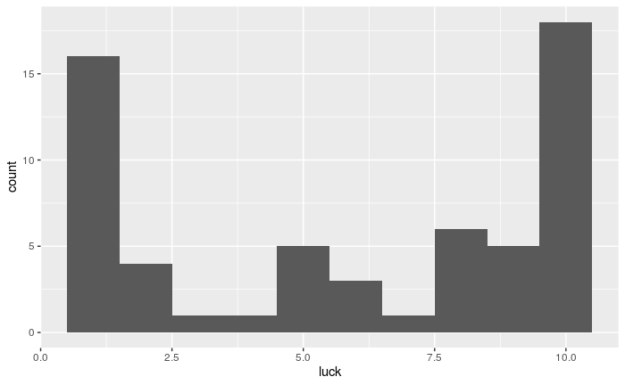

```r
ggplot(MyData1, aes(x = luck)) + geom_histogram(bins = 10)
```

The correct graph for this data would be a histogram since there is only one quantitative variable. My doubts about the 99% CI and t test are that the histogram does not follow a normal distribution.

## 2.

```r
MyData2 <- read.csv(file="sleep-dep.csv", header=TRUE, sep=",")
MyData2
```

| subject | sleep | food |
| --- | --- | --- |
| 1 | 4 hours | 3585 |
| 2 | 8 hours | 3319 |
| 3 | 4 hours | 3068 |
| 4 | 4 hours | 3187 |
| 5 | 4 hours | 5338 |
| 6 | 8 hours | 4965 |
| 7 | 4 hours | 3869 |
| 8 | 8 hours | 4100 |
| 9 | 8 hours | 3653 |
| 10 | 4 hours | 3099 |

[output cut: 20 more lines]

The table is displaying the correct data values including the number of the subject which is used for identification. The categorical variable `sleep` seems to be out of “order” since the subjects keep switching between 4 hours and 8 hours, but other than that the table seems as expected.

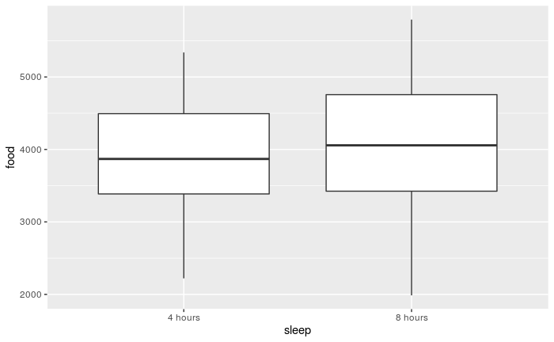

```r
ggplot(MyData2, aes(x = sleep, y = food)) + geom_boxplot()
```

The median of the men that slept 4 hours and 8 hours are very close as well as the first quantile. The third quantile of the men that slept 8 hours is about 250 higher than the men that slept 4 hours. The distribution of the men that slept 8 hours also has a bigger spread since it has a smaller minimum and larger maximum. Both distributions also dont have any outliers.

```r
t.test(food ~ sleep, data = MyData2, alternative = "less")
```

```
    Welch Two Sample t-test

data:  food by sleep
t = -0.44529, df = 27.48, p-value = 0.3298
alternative hypothesis: true difference in means is less than 0
95 percent confidence interval:
     -Inf 410.0476
sample estimates:
mean in group 4 hours mean in group 8 hours
             3924.000              4069.267
```

I used Welch-Satterthwaite t-test since the standard deviations between `sleep` seem similar but not the same as well as it being a more safe option which allows for an alternative hypothesis. Since the p-value > 0.05, do not reject the null hypothesis.